# Analysis of Factors Affecting Diabetes Prevalence in Cities/Districts of East Java in 2018

Gilang Juniar Azmi

```r
diabetes <- read.table(header = T, text = "
y   x1  x2  x3  x4  x5  x6  x7  x8  x9  x10 x11 x12
1.04    39.6    80.86   23.62   19.81   74.54   1.09    9.06    84.82   15.32   2.7 8.66    1.39
1.75    24.65   73.25   24.13   26.37   68.43   0.7 9.21    83.91   16.18   4.23    6.82    3.77
1.34    17.42   60.41   23.08   21.24   54.86   0.8 9.69    87.72   16.49   4.05    9.08    4.12
1.5 31.78   47.08   18.74   24.58   36.23   0.96    10.3    85.56   18.4    3.46    6.93    2.53
2.01    20.16   57.53   22.89   17.01   47.09   0.98    9.99    82.65   22.61   7.15    9.05    3.38
1.98    40.33   64.68   23.94   18.64   37.89   1.04    10.16   86.12   25.02   3.47    7.08    4.15
1.4 32.9    64.55   27.05   20.16   48.29   1.83    12.13   84.78   23.53   7.02    10.14   3.15
1.87    32.7    65.01   28.09   24.35   61.44   1.58    10.23   87.9    22.56   10.92   9.23    2.46
1.45    28.92   56.02   27.88   37.7    50.69   1.91    10.88   88.66   22.65   8.24    7.91    4.01
1.55    24.7    52.1    25.71   21.68   38.57   2.07    11.46   84.27   24.77   8.2 8.64    3.59
1.24    33.45   62.75   28.11   29.64   52.62   1.58    12.83   91.6    16.68   7.23    8.89    3.84
2.19    30.75   54.66   28.48   23.65   58.55   2.59    15.07   85.7    19.54   15.1    8.57    1.85
1.66    35.74   67.17   29.92   21.06   57.24   2   12.08   89.88   21.57   15.72   9.35    4
1.71    50.69   66.76   23.13   27.92   42.06   1.74    13.36   84.64   23.95   9.65    6.18    5.94
3.47    40.18   54.74   20.46   42.89   46.17   1.63    11.7    74.11   27.99   9.68    7.52    4.62
2.25    39.11   57.08   23.54   26.25   61.17   0.87    10.97   89.23   25.2    5.84    8.69    4.21
2.76    37.96   70.17   24.59   17.56   39.25   1.59    10.73   84.68   24.5    7.07    8.98    4.56
1.95    30.88   60.11   22.57   25.47   56.39   2.88    12.04   84.93   21.45   4.14    7.83    2.6
2.3 33.44   69.81   22.66   18.99   75.2    0.83    10.03   82.51   20.47   2.99    8.02    3.71
1.96    32.57   72.33   22.88   16.41   66.32   1.15    9.52    79.72   22.15   3.68    7.46    3.82
2.51    32.04   65.92   22.49   16.74   73.13   1.05    10  85.17   17.76   4.26    8.19    3.75
1.72    29.98   53.64   26.29   22.67   69.52   1.95    11.54   82.92   19.65   3.26    7.85    4.11
1.24    24.24   50.65   23.99   16.17   51.42   1.58    11.3    87.57   15.12   3.77    6.22    2.76
1.86    27.75   54.36   22.86   25.4    46.69   0.84    11.14   84.89   20.42   7.89    8.16    3.1
3.44    35.74   58.34   21.71   23.18   48.16   1.17    11.8    77  26.92   11.49   9.08    5.71
1.28    20  24.03   19.62   40.63   18.46   1.22    17.7    88.81   16.51   22.69   6.56    5.09
0.99    14.55   26.78   19.82   28.1    28.22   1   15.97   92.71   16.07   16.06   5.8 2.38
1.08    26.9    40.2    21.3    33.68   33.91   0.88    16.43   92.08   15.72   25.21   4.76    2.88
0.75    17.2    34.51   28.25   29.86   12.68   0.58    16.78   92.53   16.48   9.9 4.24    1.75
2.68    32.77   58.64   22.74   29.51   35.41   0.72    11.71   80.88   24.57   4.81    8.11    3.56
2.57    32.3    57.02   18.88   28.78   29.62   0.86    11.42   70.54   31.93   3.92    7.86    3.98
2.29    30.05   58.82   23.31   31.55   55.73   1.35    12.38   74.61   29.17   7.49    10.06   6.65
3.4 37.66   62.72   23.42   33.07   70.53   1.65    12.71   80.74   30.76   18.09   10.89   3.56
2.82    35.15   60.86   20.37   43.87   47.35   1.45    14.33   81.04   29.73   16.15   7.41    4.5
3.83    24.07   53.81   22.1    37.03   57.74   1.41    10.84   69.19   32.13   8.91    9.33    2.44
4.22    28.82   57.95   20.02   22.89   63.05   0.85    10.48   67.97   29.81   6.27    7.82    3.8
3.48    30.86   53.21   20.69   33.22   46.35   1.33    12.58   72.91   28  12.23   8.72    6.01
1.91    27.7    52.74   23.24   16.46   46.13   0.77    11.85   81.79   26.68   3.32    7.46    3.07")
```

```r
# MODEL REGRESI
# Uji hipotesis simultan
model<-lm(y ~ ., data = diabetes)
anova(model)
```

```
Analysis of Variance Table

Response: y
          Df Sum Sq Mean Sq F value    Pr(>F)
x1         1 2.7118  2.7118 14.0190 0.0009528 ***
x2         1 0.0463  0.0463  0.2392 0.6290685
x3         1 4.8942  4.8942 25.3014 3.448e-05 ***
x4         1 1.4727  1.4727  7.6134 0.0106815 *
x5         1 1.0623  1.0623  5.4920 0.0273580 *
x6         1 0.0866  0.0866  0.4478 0.5094919
x7         1 0.4049  0.4049  2.0933 0.1603663
x8         1 9.5480  9.5480 49.3601 2.303e-07 ***
x9         1 1.2115  1.2115  6.2633 0.0192284 *
x10        1 0.6076  0.6076  3.1411 0.0885301 .
x11        1 0.0015  0.0015  0.0078 0.9302717
x12        1 0.0003  0.0003  0.0017 0.9674426
Residuals 25 4.8359  0.1934
---
Signif. codes:  0 ‘***’ 0.001 ‘**’ 0.01 ‘*’ 0.05 ‘.’ 0.1 ‘ ’ 1
```

```r
summary(model)
```

```
Call:
lm(formula = y ~ ., data = diabetes)

Residuals:
     Min       1Q   Median       3Q      Max
-0.74091 -0.25109  0.03899  0.24179  0.84089

Coefficients:
             Estimate Std. Error t value Pr(>|t|)
(Intercept)  7.312650   2.821521   2.592  0.01572 *
x1           0.018287   0.017527   1.043  0.30678
x2          -0.015099   0.015994  -0.944  0.35417
x3          -0.006307   0.040369  -0.156  0.87711
x4          -0.003894   0.013410  -0.290  0.77395
x5           0.013008   0.008229   1.581  0.12649
x6          -0.093666   0.175119  -0.535  0.59746
x7          -0.066873   0.087084  -0.768  0.44973
x8          -0.072497   0.025983  -2.790  0.00994 **
x9           0.054619   0.032110   1.701  0.10135
x10          0.041387   0.024616   1.681  0.10515
x11          0.008166   0.086133   0.095  0.92523
x12         -0.003041   0.073754  -0.041  0.96744
---
Signif. codes:  0 ‘***’ 0.001 ‘**’ 0.01 ‘*’ 0.05 ‘.’ 0.1 ‘ ’ 1

Residual standard error: 0.4398 on 25 degrees of freedom
Multiple R-squared:  0.8201,    Adjusted R-squared:  0.7338
F-statistic: 9.498 on 12 and 25 DF,  p-value: 1.432e-06
```

```r
# uji hipotesis parsial
reg.X1 <- lm(y ~ x2+x3+x4+x5+x6+x7+x8+x9+x10+x11+x12, data = diabetes)
anova(reg.X1, model)
```

```
Analysis of Variance Table

Model 1: y ~ x2 + x3 + x4 + x5 + x6 + x7 + x8 + x9 + x10 + x11 + x12
Model 2: y ~ x1 + x2 + x3 + x4 + x5 + x6 + x7 + x8 + x9 + x10 + x11 +
    x12
  Res.Df    RSS Df Sum of Sq      F Pr(>F)
1     26 5.0464
2     25 4.8359  1   0.21056 1.0885 0.3068
```

```r
summary(reg.X1)
```

```
Call:
lm(formula = y ~ x2 + x3 + x4 + x5 + x6 + x7 + x8 + x9 + x10 +
    x11 + x12, data = diabetes)

Residuals:
     Min       1Q   Median       3Q      Max
-0.79686 -0.21752 -0.01551  0.24581  0.82314

Coefficients:
             Estimate Std. Error t value Pr(>|t|)
(Intercept)  6.180118   2.608784   2.369   0.0255 *
x2          -0.003953   0.011922  -0.332   0.7429
x3          -0.019605   0.038369  -0.511   0.6137
x4          -0.003321   0.013422  -0.247   0.8065
x5           0.013133   0.008242   1.593   0.1231
x6          -0.038667   0.167280  -0.231   0.8190
x7          -0.048590   0.085448  -0.569   0.5745
x8          -0.062220   0.024084  -2.583   0.0158 *
x9           0.069308   0.028908   2.398   0.0240 *
x10          0.039616   0.024599   1.610   0.1194
x11         -0.014826   0.083408  -0.178   0.8603
x12          0.014412   0.071954   0.200   0.8428
---
Signif. codes:  0 ‘***’ 0.001 ‘**’ 0.01 ‘*’ 0.05 ‘.’ 0.1 ‘ ’ 1

Residual standard error: 0.4406 on 26 degrees of freedom
Multiple R-squared:  0.8123,    Adjusted R-squared:  0.7329
F-statistic: 10.23 on 11 and 26 DF,  p-value: 6.99e-07
```

```r
reg.X2 <- lm(y ~ x1+x3+x4+x5+x6+x7+x8+x9+x10+x11+x12, data = diabetes)
anova(reg.X2, model)
```

```
Analysis of Variance Table

Model 1: y ~ x1 + x3 + x4 + x5 + x6 + x7 + x8 + x9 + x10 + x11 + x12
Model 2: y ~ x1 + x2 + x3 + x4 + x5 + x6 + x7 + x8 + x9 + x10 + x11 +
    x12
  Res.Df    RSS Df Sum of Sq      F Pr(>F)
1     26 5.0083
2     25 4.8359  1    0.1724 0.8913 0.3542
```

```r
summary(reg.X2)
```

```
Call:
lm(formula = y ~ x1 + x3 + x4 + x5 + x6 + x7 + x8 + x9 + x10 +
    x11 + x12, data = diabetes)

Residuals:
     Min       1Q   Median       3Q      Max
-0.75341 -0.14278  0.00756  0.24162  0.75557

Coefficients:
              Estimate Std. Error t value Pr(>|t|)
(Intercept)  6.3334475  2.6184667   2.419   0.0229 *
x1           0.0072337  0.0130163   0.556   0.5831
x3          -0.0214629  0.0369613  -0.581   0.5665
x4          -0.0027253  0.0133251  -0.205   0.8395
x5           0.0106922  0.0078380   1.364   0.1842
x6          -0.0653546  0.1721707  -0.380   0.7073
x7          -0.0312259  0.0783077  -0.399   0.6933
x8          -0.0676164  0.0254103  -2.661   0.0132 *
x9           0.0597489  0.0315806   1.892   0.0697 .
x10          0.0396485  0.0244952   1.619   0.1176
x11         -0.0007643  0.0854328  -0.009   0.9929
x12         -0.0044343  0.0735846  -0.060   0.9524
---
Signif. codes:  0 ‘***’ 0.001 ‘**’ 0.01 ‘*’ 0.05 ‘.’ 0.1 ‘ ’ 1

Residual standard error: 0.4389 on 26 degrees of freedom
Multiple R-squared:  0.8137,    Adjusted R-squared:  0.7349
F-statistic: 10.32 on 11 and 26 DF,  p-value: 6.379e-07
```

```r
reg.X3 <- lm(y ~ x1+x2+x4+x5+x6+x7+x8+x9+x10+x11+x12, data = diabetes)
anova(reg.X3, model)
```

```
Analysis of Variance Table

Model 1: y ~ x1 + x2 + x4 + x5 + x6 + x7 + x8 + x9 + x10 + x11 + x12
Model 2: y ~ x1 + x2 + x3 + x4 + x5 + x6 + x7 + x8 + x9 + x10 + x11 +
    x12
  Res.Df    RSS Df Sum of Sq      F Pr(>F)
1     26 4.8406
2     25 4.8359  1  0.004721 0.0244 0.8771
```

```r
summary(reg.X3)
```

```
Call:
lm(formula = y ~ x1 + x2 + x4 + x5 + x6 + x7 + x8 + x9 + x10 +
    x11 + x12, data = diabetes)

Residuals:
     Min       1Q   Median       3Q      Max
-0.74408 -0.26674  0.04246  0.23531  0.84641

Coefficients:
             Estimate Std. Error t value Pr(>|t|)
(Intercept)  7.460683   2.607313   2.861  0.00822 **
x1           0.019151   0.016316   1.174  0.25112
x2          -0.016093   0.014396  -1.118  0.27387
x4          -0.003783   0.013138  -0.288  0.77567
x5           0.012965   0.008068   1.607  0.12014
x6          -0.103545   0.160211  -0.646  0.52375
x7          -0.070788   0.081821  -0.865  0.39487
x8          -0.074580   0.021880  -3.409  0.00214 **
x9           0.053430   0.030604   1.746  0.09264 .
x10          0.042222   0.023574   1.791  0.08493 .
x11          0.006015   0.083415   0.072  0.94307
x12         -0.002030   0.072078  -0.028  0.97775
---
Signif. codes:  0 ‘***’ 0.001 ‘**’ 0.01 ‘*’ 0.05 ‘.’ 0.1 ‘ ’ 1

Residual standard error: 0.4315 on 26 degrees of freedom
Multiple R-squared:  0.8199,    Adjusted R-squared:  0.7438
F-statistic: 10.76 on 11 and 26 DF,  p-value: 4.227e-07
```

```r
reg.X4 <- lm(y ~ x1+x2+x3+x5+x6+x7+x8+x9+x10+x11+x12, data = diabetes)
anova(reg.X4, model)
```

```
Analysis of Variance Table

Model 1: y ~ x1 + x2 + x3 + x5 + x6 + x7 + x8 + x9 + x10 + x11 + x12
Model 2: y ~ x1 + x2 + x3 + x4 + x5 + x6 + x7 + x8 + x9 + x10 + x11 +
    x12
  Res.Df    RSS Df Sum of Sq      F Pr(>F)
1     26 4.8522
2     25 4.8359  1  0.016307 0.0843 0.7739
```

```r
summary(reg.X4)
```

```
Call:
lm(formula = y ~ x1 + x2 + x3 + x5 + x6 + x7 + x8 + x9 + x10 +
    x11 + x12, data = diabetes)

Residuals:
     Min       1Q   Median       3Q      Max
-0.74841 -0.26094  0.04921  0.22401  0.86461

Coefficients:
             Estimate Std. Error t value Pr(>|t|)
(Intercept)  7.197273   2.743766   2.623  0.01438 *
x1           0.018079   0.017202   1.051  0.30294
x2          -0.014671   0.015642  -0.938  0.35694
x3          -0.005687   0.039596  -0.144  0.88689
x5           0.012895   0.008073   1.597  0.12229
x6          -0.096683   0.171704  -0.563  0.57820
x7          -0.069019   0.085228  -0.810  0.42539
x8          -0.071919   0.025446  -2.826  0.00893 **
x9           0.053282   0.031213   1.707  0.09973 .
x10          0.039406   0.023231   1.696  0.10177
x11          0.011124   0.084008   0.132  0.89567
x12         -0.005369   0.072014  -0.075  0.94114
---
Signif. codes:  0 ‘***’ 0.001 ‘**’ 0.01 ‘*’ 0.05 ‘.’ 0.1 ‘ ’ 1

Residual standard error: 0.432 on 26 degrees of freedom
Multiple R-squared:  0.8195,    Adjusted R-squared:  0.7432
F-statistic: 10.73 on 11 and 26 DF,  p-value: 4.351e-07
```

```r
reg.X5 <- lm(y ~ x1+x2+x3+x4+x6+x7+x8+x9+x10+x11+x12, data = diabetes)
anova(reg.X5, model)
```

```
Analysis of Variance Table

Model 1: y ~ x1 + x2 + x3 + x4 + x6 + x7 + x8 + x9 + x10 + x11 + x12
Model 2: y ~ x1 + x2 + x3 + x4 + x5 + x6 + x7 + x8 + x9 + x10 + x11 +
    x12
  Res.Df    RSS Df Sum of Sq     F Pr(>F)
1     26 5.3193
2     25 4.8359  1   0.48339 2.499 0.1265
```

```r
summary(reg.X5)
```

```
Call:
lm(formula = y ~ x1 + x2 + x3 + x4 + x6 + x7 + x8 + x9 + x10 +
    x11 + x12, data = diabetes)

Residuals:
     Min       1Q   Median       3Q      Max
-0.81541 -0.22501  0.05091  0.25110  0.76149

Coefficients:
             Estimate Std. Error t value Pr(>|t|)
(Intercept)  8.912125   2.708724   3.290  0.00288 **
x1           0.018690   0.018024   1.037  0.30930
x2          -0.007563   0.015700  -0.482  0.63406
x3          -0.004203   0.041493  -0.101  0.92010
x4          -0.002894   0.013776  -0.210  0.83525
x6          -0.051905   0.178035  -0.292  0.77295
x7          -0.098048   0.087233  -1.124  0.27129
x8          -0.084611   0.025533  -3.314  0.00271 **
x9           0.036058   0.030736   1.173  0.25136
x10          0.049513   0.024757   2.000  0.05606 .
x11          0.041674   0.085857   0.485  0.63146
x12         -0.019280   0.075111  -0.257  0.79944
---
Signif. codes:  0 ‘***’ 0.001 ‘**’ 0.01 ‘*’ 0.05 ‘.’ 0.1 ‘ ’ 1

Residual standard error: 0.4523 on 26 degrees of freedom
Multiple R-squared:  0.8021,    Adjusted R-squared:  0.7184
F-statistic: 9.582 on 11 and 26 DF,  p-value: 1.317e-06
```

```r
reg.X6 <- lm(y ~ x1+x2+x3+x4+x5+x7+x8+x9+x10+x11+x12, data = diabetes)
anova(reg.X6, model)
```

```
Analysis of Variance Table

Model 1: y ~ x1 + x2 + x3 + x4 + x5 + x7 + x8 + x9 + x10 + x11 + x12
Model 2: y ~ x1 + x2 + x3 + x4 + x5 + x6 + x7 + x8 + x9 + x10 + x11 +
    x12
  Res.Df    RSS Df Sum of Sq      F Pr(>F)
1     26 4.8912
2     25 4.8359  1   0.05534 0.2861 0.5975
```

```r
summary(reg.X6)
```

```
Call:
lm(formula = y ~ x1 + x2 + x3 + x4 + x5 + x7 + x8 + x9 + x10 +
    x11 + x12, data = diabetes)

Residuals:
     Min       1Q   Median       3Q      Max
-0.72035 -0.27496  0.04094  0.22035  0.81149

Coefficients:
              Estimate Std. Error t value Pr(>|t|)
(Intercept)  7.4132873  2.7763207   2.670  0.01290 *
x1           0.0154647  0.0164834   0.938  0.35678
x2          -0.0136341  0.0155395  -0.877  0.38831
x3          -0.0141030  0.0371247  -0.380  0.70712
x4          -0.0043192  0.0132016  -0.327  0.74616
x5           0.0123439  0.0080219   1.539  0.13594
x7          -0.0741566  0.0848237  -0.874  0.38999
x8          -0.0708873  0.0254514  -2.785  0.00985 **
x9           0.0560612  0.0315542   1.777  0.08733 .
x10          0.0418429  0.0242608   1.725  0.09645 .
x11         -0.0033886  0.0822274  -0.041  0.96744
x12          0.0005625  0.0724301   0.008  0.99386
---
Signif. codes:  0 ‘***’ 0.001 ‘**’ 0.01 ‘*’ 0.05 ‘.’ 0.1 ‘ ’ 1

Residual standard error: 0.4337 on 26 degrees of freedom
Multiple R-squared:  0.8181,    Adjusted R-squared:  0.7411
F-statistic: 10.63 on 11 and 26 DF,  p-value: 4.794e-07
```

```r
reg.X7 <- lm(y ~ x1+x2+x3+x4+x5+x6+x8+x9+x10+x11+x12, data = diabetes)
anova(reg.X7, model)
```

```
Analysis of Variance Table

Model 1: y ~ x1 + x2 + x3 + x4 + x5 + x6 + x8 + x9 + x10 + x11 + x12
Model 2: y ~ x1 + x2 + x3 + x4 + x5 + x6 + x7 + x8 + x9 + x10 + x11 +
    x12
  Res.Df    RSS Df Sum of Sq      F Pr(>F)
1     26 4.9500
2     25 4.8359  1   0.11407 0.5897 0.4497
```

```r
summary(reg.X7)
```

```
Call:
lm(formula = y ~ x1 + x2 + x3 + x4 + x5 + x6 + x8 + x9 + x10 +
    x11 + x12, data = diabetes)

Residuals:
     Min       1Q   Median       3Q      Max
-0.82574 -0.24581  0.02024  0.21953  0.85361

Coefficients:
             Estimate Std. Error t value Pr(>|t|)
(Intercept)  6.227832   2.423054   2.570   0.0162 *
x1           0.015578   0.017033   0.915   0.3688
x2          -0.009774   0.014298  -0.684   0.5003
x3          -0.015227   0.038355  -0.397   0.6946
x4          -0.004768   0.013256  -0.360   0.7220
x5           0.014439   0.007951   1.816   0.0809 .
x6          -0.114694   0.171595  -0.668   0.5098
x8          -0.070411   0.025636  -2.747   0.0108 *
x9           0.057184   0.031683   1.805   0.0827 .
x10          0.029109   0.018568   1.568   0.1290
x11          0.025586   0.082434   0.310   0.7587
x12         -0.006008   0.073069  -0.082   0.9351
---
Signif. codes:  0 ‘***’ 0.001 ‘**’ 0.01 ‘*’ 0.05 ‘.’ 0.1 ‘ ’ 1

Residual standard error: 0.4363 on 26 degrees of freedom
Multiple R-squared:  0.8159,    Adjusted R-squared:  0.738
F-statistic: 10.47 on 11 and 26 DF,  p-value: 5.538e-07
```

```r
reg.X8 <- lm(y ~ x1+x2+x3+x4+x5+x6+x7+x9+x10+x11+x12, data = diabetes)
anova(reg.X8, model)
```

```
Analysis of Variance Table

Model 1: y ~ x1 + x2 + x3 + x4 + x5 + x6 + x7 + x9 + x10 + x11 + x12
Model 2: y ~ x1 + x2 + x3 + x4 + x5 + x6 + x7 + x8 + x9 + x10 + x11 +
    x12
  Res.Df    RSS Df Sum of Sq     F   Pr(>F)
1     26 6.3418
2     25 4.8359  1    1.5059 7.785 0.009936 **
---
Signif. codes:  0 ‘***’ 0.001 ‘**’ 0.01 ‘*’ 0.05 ‘.’ 0.1 ‘ ’ 1
```

```r
summary(reg.X8)
```

```
Call:
lm(formula = y ~ x1 + x2 + x3 + x4 + x5 + x6 + x7 + x9 + x10 +
    x11 + x12, data = diabetes)

Residuals:
    Min      1Q  Median      3Q     Max
-0.6918 -0.3511 -0.1007  0.2997  0.7904

Coefficients:
              Estimate Std. Error t value Pr(>|t|)
(Intercept)  0.6248397  1.6715186   0.374   0.7116
x1          -0.0002535  0.0182128  -0.014   0.9890
x2          -0.0062197  0.0176005  -0.353   0.7267
x3          -0.0640951  0.0389099  -1.647   0.1115
x4          -0.0010263  0.0150145  -0.068   0.9460
x5           0.0197787  0.0088291   2.240   0.0338 *
x6          -0.0370613  0.1953214  -0.190   0.8510
x7          -0.0414609  0.0972526  -0.426   0.6734
x9           0.1225817  0.0234942   5.218 1.89e-05 ***
x10          0.0233905  0.0266757   0.877   0.3886
x11         -0.0160989  0.0962266  -0.167   0.8684
x12          0.0193876  0.0823266   0.235   0.8157
---
Signif. codes:  0 ‘***’ 0.001 ‘**’ 0.01 ‘*’ 0.05 ‘.’ 0.1 ‘ ’ 1

Residual standard error: 0.4939 on 26 degrees of freedom
Multiple R-squared:  0.7641,    Adjusted R-squared:  0.6643
F-statistic: 7.656 on 11 and 26 DF,  p-value: 1.062e-05
```

```r
reg.X9 <- lm(y ~ x1+x2+x3+x4+x5+x6+x7+x8+x10+x11+x12, data = diabetes)
anova(reg.X9, model)
```

```
Analysis of Variance Table

Model 1: y ~ x1 + x2 + x3 + x4 + x5 + x6 + x7 + x8 + x10 + x11 + x12
Model 2: y ~ x1 + x2 + x3 + x4 + x5 + x6 + x7 + x8 + x9 + x10 + x11 +
    x12
  Res.Df    RSS Df Sum of Sq      F Pr(>F)
1     26 5.3956
2     25 4.8359  1    0.5597 2.8934 0.1013
```

```r
summary(reg.X9)
```

```
Call:
lm(formula = y ~ x1 + x2 + x3 + x4 + x5 + x6 + x7 + x8 + x10 +
    x11 + x12, data = diabetes)

Residuals:
     Min       1Q   Median       3Q      Max
-0.95309 -0.29637  0.05352  0.23731  0.84679

Coefficients:
              Estimate Std. Error t value Pr(>|t|)
(Intercept) 10.6894971  2.0767108   5.147 2.28e-05 ***
x1           0.0313587  0.0163165   1.922   0.0656 .
x2          -0.0197025  0.0163269  -1.207   0.2384
x3           0.0099716  0.0406208   0.245   0.8080
x4          -0.0006214  0.0137464  -0.045   0.9643
x5           0.0078896  0.0079326   0.995   0.3291
x6          -0.1186736  0.1807429  -0.657   0.5172
x7          -0.0822797  0.0897101  -0.917   0.3675
x8          -0.1060247  0.0175359  -6.046 2.19e-06 ***
x10          0.0468167  0.0252809   1.852   0.0754 .
x11          0.0683810  0.0813312   0.841   0.4081
x12         -0.0051364  0.0763814  -0.067   0.9469
---
Signif. codes:  0 ‘***’ 0.001 ‘**’ 0.01 ‘*’ 0.05 ‘.’ 0.1 ‘ ’ 1

Residual standard error: 0.4555 on 26 degrees of freedom
Multiple R-squared:  0.7993,    Adjusted R-squared:  0.7144
F-statistic: 9.413 on 11 and 26 DF,  p-value: 1.562e-06
```

```r
reg.X10 <- lm(y ~ x1+x2+x3+x4+x5+x6+x7+x8+x9+x11+x12, data = diabetes)
anova(reg.X10, model)
```

```
Analysis of Variance Table

Model 1: y ~ x1 + x2 + x3 + x4 + x5 + x6 + x7 + x8 + x9 + x11 + x12
Model 2: y ~ x1 + x2 + x3 + x4 + x5 + x6 + x7 + x8 + x9 + x10 + x11 +
    x12
  Res.Df    RSS Df Sum of Sq      F Pr(>F)
1     26 5.3827
2     25 4.8359  1   0.54683 2.8269 0.1051
```

```r
summary(reg.X10)
```

```
Call:
lm(formula = y ~ x1 + x2 + x3 + x4 + x5 + x6 + x7 + x8 + x9 +
    x11 + x12, data = diabetes)

Residuals:
     Min       1Q   Median       3Q      Max
-0.91839 -0.16655  0.03269  0.15747  0.91502

Coefficients:
             Estimate Std. Error t value Pr(>|t|)
(Intercept)  5.108909   2.584905   1.976   0.0588 .
x1           0.016254   0.018090   0.899   0.3772
x2          -0.013087   0.016500  -0.793   0.4349
x3          -0.021039   0.040767  -0.516   0.6102
x4           0.002357   0.013330   0.177   0.8610
x5           0.015897   0.008325   1.909   0.0673 .
x6          -0.103852   0.181058  -0.574   0.5712
x7           0.028231   0.068500   0.412   0.6836
x8          -0.061050   0.025941  -2.353   0.0264 *
x9           0.061620   0.032938   1.871   0.0727 .
x11          0.046492   0.085931   0.541   0.5931
x12         -0.001286   0.076293  -0.017   0.9867
---
Signif. codes:  0 ‘***’ 0.001 ‘**’ 0.01 ‘*’ 0.05 ‘.’ 0.1 ‘ ’ 1

Residual standard error: 0.455 on 26 degrees of freedom
Multiple R-squared:  0.7998,    Adjusted R-squared:  0.7151
F-statistic: 9.441 on 11 and 26 DF,  p-value: 1.518e-06
```

```r
reg.X11 <- lm(y ~ x1+x2+x3+x4+x5+x6+x7+x8+x9+x10+x12, data = diabetes)
anova(reg.X11, model)
```

```
Analysis of Variance Table

Model 1: y ~ x1 + x2 + x3 + x4 + x5 + x6 + x7 + x8 + x9 + x10 + x12
Model 2: y ~ x1 + x2 + x3 + x4 + x5 + x6 + x7 + x8 + x9 + x10 + x11 +
    x12
  Res.Df    RSS Df Sum of Sq     F Pr(>F)
1     26 4.8376
2     25 4.8359  1 0.0017385 0.009 0.9252
```

```r
summary(reg.X11)
```

```
Call:
lm(formula = y ~ x1 + x2 + x3 + x4 + x5 + x6 + x7 + x8 + x9 +
    x10 + x12, data = diabetes)

Residuals:
     Min       1Q   Median       3Q      Max
-0.73316 -0.25592  0.03911  0.25119  0.84347

Coefficients:
             Estimate Std. Error t value Pr(>|t|)
(Intercept)  7.322226   2.765452   2.648  0.01359 *
x1           0.017862   0.016618   1.075  0.29232
x2          -0.014933   0.015591  -0.958  0.34700
x3          -0.005695   0.039083  -0.146  0.88527
x4          -0.004044   0.013060  -0.310  0.75929
x5           0.013200   0.007822   1.688  0.10347
x6          -0.089503   0.166260  -0.538  0.59493
x7          -0.069048   0.082393  -0.838  0.40965
x8          -0.072249   0.025353  -2.850  0.00845 **
x9           0.055870   0.028709   1.946  0.06253 .
x10          0.042005   0.023281   1.804  0.08279 .
x12         -0.001656   0.070902  -0.023  0.98155
---
Signif. codes:  0 ‘***’ 0.001 ‘**’ 0.01 ‘*’ 0.05 ‘.’ 0.1 ‘ ’ 1

Residual standard error: 0.4313 on 26 degrees of freedom
Multiple R-squared:  0.8201,    Adjusted R-squared:  0.7439
F-statistic: 10.77 on 11 and 26 DF,  p-value: 4.196e-07
```

```r
reg.X12 <- lm(y ~ x1+x2+x3+x4+x5+x6+x7+x8+x9+x10+x11, data = diabetes)
anova(reg.X12, model)
```

```
Analysis of Variance Table

Model 1: y ~ x1 + x2 + x3 + x4 + x5 + x6 + x7 + x8 + x9 + x10 + x11
Model 2: y ~ x1 + x2 + x3 + x4 + x5 + x6 + x7 + x8 + x9 + x10 + x11 +
    x12
  Res.Df    RSS Df  Sum of Sq      F Pr(>F)
1     26 4.8362
2     25 4.8359  1 0.00032877 0.0017 0.9674
```

```r
summary(reg.X12)
```

```
Call:
lm(formula = y ~ x1 + x2 + x3 + x4 + x5 + x6 + x7 + x8 + x9 +
    x10 + x11, data = diabetes)

Residuals:
     Min       1Q   Median       3Q      Max
-0.74747 -0.25430  0.04021  0.24022  0.83957

Coefficients:
             Estimate Std. Error t value Pr(>|t|)
(Intercept)  7.299815   2.749929   2.655  0.01337 *
x1           0.018123   0.016740   1.083  0.28891
x2          -0.015112   0.015680  -0.964  0.34404
x3          -0.006161   0.039433  -0.156  0.87706
x4          -0.003954   0.013072  -0.302  0.76472
x5           0.013055   0.007990   1.634  0.11434
x6          -0.093007   0.171006  -0.544  0.59116
x7          -0.067061   0.085278  -0.786  0.43875
x8          -0.072381   0.025328  -2.858  0.00829 **
x9           0.054641   0.031483   1.736  0.09448 .
x10          0.041373   0.024136   1.714  0.09840 .
x11          0.007462   0.082790   0.090  0.92887
---
Signif. codes:  0 ‘***’ 0.001 ‘**’ 0.01 ‘*’ 0.05 ‘.’ 0.1 ‘ ’ 1

Residual standard error: 0.4313 on 26 degrees of freedom
Multiple R-squared:  0.8201,    Adjusted R-squared:  0.744
F-statistic: 10.78 on 11 and 26 DF,  p-value: 4.181e-07
```

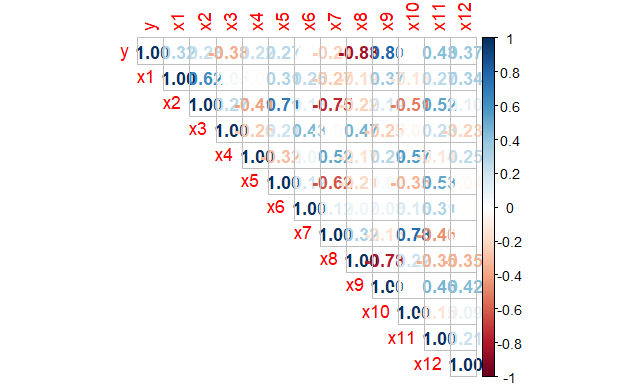

```r
# == Matriks Korelasi == #
library(corrplot)
corrplot(cor(diabetes[,c(1:13)]), method="number", type="upper", sig.level=0.05)
```

```r
korelasi = cor(diabetes)
korelasi
```

```
               y          x1         x2          x3          x4
y    1.000000000  0.31760066  0.2303051 -0.37658213  0.22282278
x1   0.317600659  1.00000000  0.6229664  0.05451102 -0.01314041
x2   0.230305138  0.62296636  1.0000000  0.26870466 -0.40556614
x3  -0.376582129  0.05451102  0.2687047  1.00000000 -0.26082300
x4   0.222822779 -0.01314041 -0.4055661 -0.26082300  1.00000000
x5   0.270794544  0.30825629  0.7091915  0.20678202 -0.31766848
x6   0.002878903  0.25194282  0.1251288  0.43308387  0.07617680
x7  -0.241215185 -0.26671372 -0.7459448 -0.02803098  0.52096028
x8  -0.833400650 -0.18644533 -0.2238500  0.46786686 -0.16580257
x9   0.798504795  0.37103514  0.1881532 -0.25242580  0.28561034
x10 -0.003992592 -0.13127128 -0.5120496 -0.04808671  0.56804778
x11  0.428133609  0.26807460  0.5215962  0.23334214 -0.13650568
x12  0.370093132  0.33609845  0.1044430 -0.23320004  0.25068781
             x5           x6           x7          x8           x9
y    0.27079454  0.002878903 -0.241215185 -0.83340065  0.798504795
x1   0.30825629  0.251942815 -0.266713724 -0.18644533  0.371035142
x2   0.70919145  0.125128754 -0.745944758 -0.22385002  0.188153191
x3   0.20678202  0.433083867 -0.028030977  0.46786686 -0.252425801
x4  -0.31766848  0.076176803  0.520960283 -0.16580257  0.285610338
x5   1.00000000  0.191876184 -0.623152945 -0.20824945  0.044618978
x6   0.19187618  1.000000000  0.120726498  0.07127549  0.082589917
x7  -0.62315294  0.120726498  1.000000000  0.32021406 -0.155213931
x8  -0.20824945  0.071275492  0.320214061  1.00000000 -0.781884535
x9   0.04461898  0.082589917 -0.155213931 -0.78188453  1.000000000
x10 -0.34911125  0.157560137  0.778143837  0.21749388 -0.009348454
x11  0.52712079  0.308943711 -0.455986614 -0.35184091  0.463726420
x12 -0.03933635 -0.002911456  0.002772414 -0.35227026  0.421963933
             x10        x11          x12
y   -0.003992592  0.4281336  0.370093132
x1  -0.131271277  0.2680746  0.336098448
x2  -0.512049639  0.5215962  0.104443049
x3  -0.048086709  0.2333421 -0.233200038
x4   0.568047780 -0.1365057  0.250687808
x5  -0.349111246  0.5271208 -0.039336350
x6   0.157560137  0.3089437 -0.002911456
x7   0.778143837 -0.4559866  0.002772414
x8   0.217493878 -0.3518409 -0.352270257
x9  -0.009348454  0.4637264  0.421963933
x10  1.000000000 -0.1473577  0.090236846
x11 -0.147357698  1.0000000  0.211443896
x12  0.090236846  0.2114439  1.000000000
```

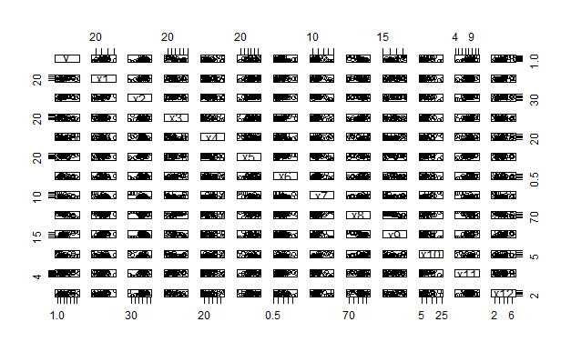

```r
# == Scatter Plot Antarpeubah == #
plot(diabetes[,1:13], pch = 21)
```

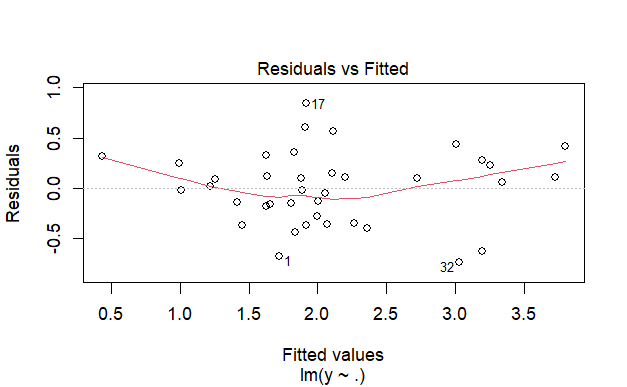

```r
#  ===== Eksplorasi asumsi =====
plot(model,1)                # plot sisaan vs yduga
```

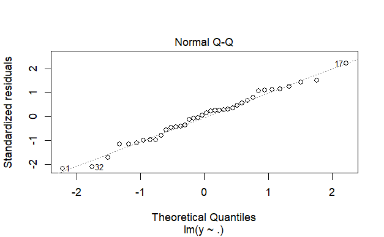

```r
plot(model,2)                # qq-plot
```

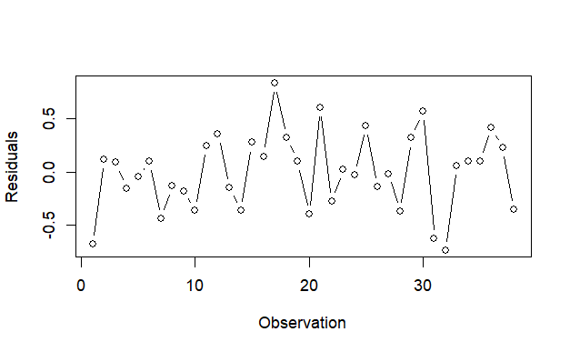

```r
plot(x = 1:dim(diabetes)[1],
     y = model$residuals,
     type = 'b',
     ylab = "Residuals",
     xlab = "Observation")       # plot sisaan vs urutan
```

```r
# ===== Uji Asumsi Formal =====
# Asumsi GAUSS MARKOV
# 1 Nilai harapan sisaan sama dengan nol
t.test(model$residuals,
       mu = 0,
       conf.level = 0.95)
```

```
    One Sample t-test

data:  model$residuals
t = -1.9312e-16, df = 37, p-value = 1
alternative hypothesis: true mean is not equal to 0
95 percent confidence interval:
 -0.11883  0.11883
sample estimates:
    mean of x
-1.132563e-17
```

Asumsi terpenuhi karena p-value = 1

```r
# ASUMSI NORMALITAS SISAAN
# Menggunakan Shapiro Wilk Test
ks.test(model$residuals, "pnorm", mean=mean(model$residuals), sd=sd(model$residuals))
```

```
    Exact one-sample Kolmogorov-Smirnov test

data:  model$residuals
D = 0.073351, p-value = 0.9774
alternative hypothesis: two-sided
```

```r
library(car)
shapiro.test(model$residuals)
```

```
    Shapiro-Wilk normality test

data:  model$residuals
W = 0.98806, p-value = 0.9514
```

Hipotesis H0 : Residual berdistribusi normal H1 : Residual tidak berdistribusi normal Keputusan : Karena p-value (0.9514) > alpha (0.05), maka gagal tolak H0 Kesimpulan : Dengan tingkat keyakinan 95%, kita yakin bahwa residual berdistribusi normal.

```r
# Menggunakan Uji Jarque Bera
library("tseries")
residual=resid(model)
jarque.bera.test(residual)
```

```
    Jarque Bera Test

data:  residual
X-squared = 0.14787, df = 2, p-value = 0.9287
```

Hipotesis H0 : Residual berdistribusi normal H1 : Residual tidak berdistribusi normal Keputusan : Karena p-value (0.9287) > alpha (0.05), maka gagal tolak H0 Kesimpulan : Dengan tingkat keyakinan 95%, kita yakin bahwa residual berdistribusi normal.

```r
# UJI AUTOKORELASI
# Menggunakan Runs-test
library(randtests)
runs.test(model$residuals)
```

```
    Runs Test

data:  model$residuals
statistic = -0.98675, runs = 17, n1 = 19, n2 = 19, n = 38,
p-value = 0.3238
alternative hypothesis: nonrandomness
```

Hipotesis H0 : Tidak ada auto korelasi dari galat H1 : Ada auto korelasi dari galat Keputusan : Karena p-value (0.3238) > alpha (0.05), maka gagal tolak H0 Kesimpulan : Dengan tingkat keyakinan 95%, kita yakin bahwa tidak ada auto korelasi pada galat.

```r
# Menggunakan Uji Durbin Watson
library(lmtest)
dwtest(model)
```

```
    Durbin-Watson test

data:  model
DW = 1.8475, p-value = 0.1235
alternative hypothesis: true autocorrelation is greater than 0
```

Hipotesis H0 : Tidak ada auto korelasi dari galat H1 : Ada auto korelasi dari galat Keputusan : Karena p-value (0.1235) > alpha (0.05), maka gagal tolak H0 Kesimpulan : Dengan tingkat keyakinan 95%, kita yakin bahwa tidak ada auto korelasi pada galat.

```r
# UJI KEHOMOGENAN RAGAM (HOMOSKEDASTISITAS)
# Menggunakan Uji Breusch Pagan
bptest(model, data=diabetes)
```

```
    studentized Breusch-Pagan test

data:  model
BP = 16.139, df = 12, p-value = 0.185
```

Hipotesis H0 : Ragam Homogen H1 : Ragam tidak homogen Keputusan : Karena p-value (0.185) > alpha (0.05) maka gagal tolak H0. Kesimpulan : Dengan tingkat keyakinan 95%, kita yakin bahwa ragam homogen

```r
# UJI MULTIKOLINEARITAS
vif(model)
```

```
      x1       x2       x3       x4       x5       x6       x7
3.151353 6.602245 2.559313 1.973799 2.928980 1.670041 6.583254
      x8       x9      x10      x11      x12
5.205626 5.167796 3.642002 2.776293 1.438482
```

Semua variabel memiliki nilai VIF < 10 sehingga tidak mengindikasikan adanya multikolinieritas

```r
library(olsrr)
ols_vif_tol(model)
```

| Variables | Tolerance | VIF |
| --- | --- | --- |
| x1 | 0.3173240 | 3.151353 |
| x2 | 0.1514636 | 6.602245 |
| x3 | 0.3907299 | 2.559313 |
| x4 | 0.5066371 | 1.973799 |
| x5 | 0.3414158 | 2.928980 |
| x6 | 0.5987876 | 1.670041 |
| x7 | 0.1519006 | 6.583254 |
| x8 | 0.1920999 | 5.205626 |
| x9 | 0.1935061 | 5.167796 |
| x10 | 0.2745742 | 3.642002 |

[output cut: 2 more lines]

Semua variabel memiliki nilai toleransi lebih dari 0.1 dan VIF < 10 sehingga tidak mengindikasikan adanya multikolinieritas

```r
#UJI LINEARITAS
lmtest::resettest(model, power=2)
```

```
    RESET test

data:  model
RESET = 2.4582, df1 = 1, df2 = 24, p-value = 0.13
```

p-value = 0.13 > α(0,05) Kesimpulan: model linier.

```r
library(olsrr)
ols_step_all_possible(model)
```

|  | Index | N | Predictors | R-Square | Adj. R-Square | Mallow's Cp |
| --- | --- | --- | --- | --- | --- | --- |
| 8 | 1 | 1 | x8 | 6.945566e-01 | 0.6860721057 | 8.4505640 |
| 9 | 2 | 1 | x9 | 6.376099e-01 | 0.6275435167 | 16.3650299 |
| 11 | 3 | 1 | x11 | 1.832984e-01 | 0.1606122316 | 79.5053140 |
| 3 | 4 | 1 | x3 | 1.418141e-01 | 0.1179756030 | 85.2708065 |
| 12 | 5 | 1 | x12 | 1.369689e-01 | 0.1129958412 | 85.9441895 |
| 1 | 6 | 1 | x1 | 1.008702e-01 | 0.0758943505 | 90.9611989 |
| 5 | 7 | 1 | x5 | 7.332969e-02 | 0.0475888432 | 94.7887809 |
| 7 | 8 | 1 | x7 | 5.818477e-02 | 0.0320232311 | 96.8936242 |
| 2 | 9 | 1 | x2 | 5.304046e-02 | 0.0267360246 | 97.6085810 |
| 4 | 10 | 1 | x4 | 4.964999e-02 | 0.0232513793 | 98.0797885 |

[output cut: 990 more lines]

```r
###BEST SUBSET REGRESSION###
library(MASS)
#---Stepwise Regression Model----
step.model <- stepAIC(model, direction = "both", trace = F)
summary(step.model)
```

```
Call:
lm(formula = y ~ x5 + x8 + x9 + x10, data = diabetes)

Residuals:
     Min       1Q   Median       3Q      Max
-0.87343 -0.24693  0.02381  0.16377  0.82565

Coefficients:
             Estimate Std. Error t value Pr(>|t|)
(Intercept)  6.031956   1.951721   3.091 0.004040 **
x5           0.011735   0.004773   2.459 0.019363 *
x8          -0.073690   0.018033  -4.086 0.000263 ***
x9           0.060262   0.021624   2.787 0.008757 **
x10          0.029051   0.013051   2.226 0.032966 *
---
Signif. codes:  0 ‘***’ 0.001 ‘**’ 0.01 ‘*’ 0.05 ‘.’ 0.1 ‘ ’ 1

Residual standard error: 0.4019 on 33 degrees of freedom
Multiple R-squared:  0.8017,    Adjusted R-squared:  0.7777
F-statistic: 33.36 on 4 and 33 DF,  p-value: 3.619e-11
```

```r
#---Backward Regression Model----
back.model <- stepAIC(model, direction = "backward", trace =  F)
summary(back.model)
```

```
Call:
lm(formula = y ~ x5 + x8 + x9 + x10, data = diabetes)

Residuals:
     Min       1Q   Median       3Q      Max
-0.87343 -0.24693  0.02381  0.16377  0.82565

Coefficients:
             Estimate Std. Error t value Pr(>|t|)
(Intercept)  6.031956   1.951721   3.091 0.004040 **
x5           0.011735   0.004773   2.459 0.019363 *
x8          -0.073690   0.018033  -4.086 0.000263 ***
x9           0.060262   0.021624   2.787 0.008757 **
x10          0.029051   0.013051   2.226 0.032966 *
---
Signif. codes:  0 ‘***’ 0.001 ‘**’ 0.01 ‘*’ 0.05 ‘.’ 0.1 ‘ ’ 1

Residual standard error: 0.4019 on 33 degrees of freedom
Multiple R-squared:  0.8017,    Adjusted R-squared:  0.7777
F-statistic: 33.36 on 4 and 33 DF,  p-value: 3.619e-11
```

```r
#---Forward Regression Model----
fwd.model <- stepAIC(model, direction = "forward", trace = F)
summary(fwd.model)
```

```
Call:
lm(formula = y ~ x1 + x2 + x3 + x4 + x5 + x6 + x7 + x8 + x9 +
    x10 + x11 + x12, data = diabetes)

Residuals:
     Min       1Q   Median       3Q      Max
-0.74091 -0.25109  0.03899  0.24179  0.84089

Coefficients:
             Estimate Std. Error t value Pr(>|t|)
(Intercept)  7.312650   2.821521   2.592  0.01572 *
x1           0.018287   0.017527   1.043  0.30678
x2          -0.015099   0.015994  -0.944  0.35417
x3          -0.006307   0.040369  -0.156  0.87711
x4          -0.003894   0.013410  -0.290  0.77395
x5           0.013008   0.008229   1.581  0.12649
x6          -0.093666   0.175119  -0.535  0.59746
x7          -0.066873   0.087084  -0.768  0.44973
x8          -0.072497   0.025983  -2.790  0.00994 **
x9           0.054619   0.032110   1.701  0.10135
x10          0.041387   0.024616   1.681  0.10515
x11          0.008166   0.086133   0.095  0.92523
x12         -0.003041   0.073754  -0.041  0.96744
---
Signif. codes:  0 ‘***’ 0.001 ‘**’ 0.01 ‘*’ 0.05 ‘.’ 0.1 ‘ ’ 1

Residual standard error: 0.4398 on 25 degrees of freedom
Multiple R-squared:  0.8201,    Adjusted R-squared:  0.7338
F-statistic: 9.498 on 12 and 25 DF,  p-value: 1.432e-06
```

```r
# MODEL REGRESI BARU
diabetes2 <- read.table(header = T, text = "
y   x5  x8  x9  x10
1.04    74.54   84.82   15.32   2.7
1.75    68.43   83.91   16.18   4.23
1.34    54.86   87.72   16.49   4.05
1.5 36.23   85.56   18.4    3.46
2.01    47.09   82.65   22.61   7.15
1.98    37.89   86.12   25.02   3.47
1.4 48.29   84.78   23.53   7.02
1.87    61.44   87.9    22.56   10.92
1.45    50.69   88.66   22.65   8.24
1.55    38.57   84.27   24.77   8.2
1.24    52.62   91.6    16.68   7.23
2.19    58.55   85.7    19.54   15.1
1.66    57.24   89.88   21.57   15.72
1.71    42.06   84.64   23.95   9.65
3.47    46.17   74.11   27.99   9.68
2.25    61.17   89.23   25.2    5.84
2.76    39.25   84.68   24.5    7.07
1.95    56.39   84.93   21.45   4.14
2.3 75.2    82.51   20.47   2.99
1.96    66.32   79.72   22.15   3.68
2.51    73.13   85.17   17.76   4.26
1.72    69.52   82.92   19.65   3.26
1.24    51.42   87.57   15.12   3.77
1.86    46.69   84.89   20.42   7.89
3.44    48.16   77  26.92   11.49
1.28    18.46   88.81   16.51   22.69
0.99    28.22   92.71   16.07   16.06
1.08    33.91   92.08   15.72   25.21
0.75    12.68   92.53   16.48   9.9
2.68    35.41   80.88   24.57   4.81
2.57    29.62   70.54   31.93   3.92
2.29    55.73   74.61   29.17   7.49
3.4 70.53   80.74   30.76   18.09
2.82    47.35   81.04   29.73   16.15
3.83    57.74   69.19   32.13   8.91
4.22    63.05   67.97   29.81   6.27
3.48    46.35   72.91   28  12.23
1.91    46.13   81.79   26.68   3.32")
```

```r
# MODEL REGRESI
# Uji hipotesis simultan
model2<-lm(y ~ ., data = diabetes2)
anova(model2)
```

```
Analysis of Variance Table

Response: y
          Df  Sum Sq Mean Sq  F value    Pr(>F)
x5         1  1.9714  1.9714  12.2038  0.001380 **
x8         1 16.9666 16.9666 105.0321 8.724e-12 ***
x9         1  1.8146  1.8146  11.2336  0.002025 **
x10        1  0.8003  0.8003   4.9546  0.032966 *
Residuals 33  5.3307  0.1615
---
Signif. codes:  0 ‘***’ 0.001 ‘**’ 0.01 ‘*’ 0.05 ‘.’ 0.1 ‘ ’ 1
```

```r
summary(model2)
```

```
Call:
lm(formula = y ~ ., data = diabetes2)

Residuals:
     Min       1Q   Median       3Q      Max
-0.87343 -0.24693  0.02381  0.16377  0.82565

Coefficients:
             Estimate Std. Error t value Pr(>|t|)
(Intercept)  6.031956   1.951721   3.091 0.004040 **
x5           0.011735   0.004773   2.459 0.019363 *
x8          -0.073690   0.018033  -4.086 0.000263 ***
x9           0.060262   0.021624   2.787 0.008757 **
x10          0.029051   0.013051   2.226 0.032966 *
---
Signif. codes:  0 ‘***’ 0.001 ‘**’ 0.01 ‘*’ 0.05 ‘.’ 0.1 ‘ ’ 1

Residual standard error: 0.4019 on 33 degrees of freedom
Multiple R-squared:  0.8017,    Adjusted R-squared:  0.7777
F-statistic: 33.36 on 4 and 33 DF,  p-value: 3.619e-11
```

```r
ri = rstandard(model2)
hii = hatvalues(model2)
Obs = c(1:38)
summ <- cbind.data.frame(Obs, hii, ri)
View(summ)
```

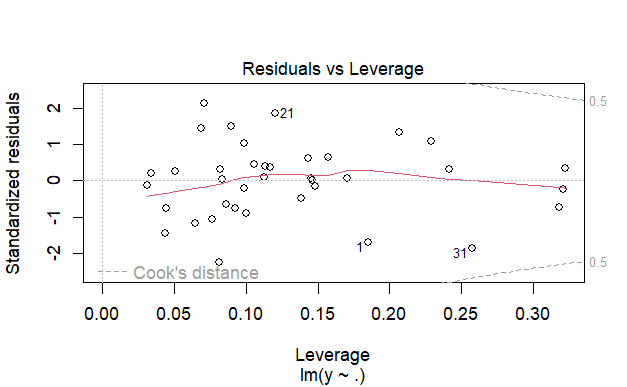

```r
#Eksploratif amatan berpengaruh (jarak cook)
plot(model2, 5)
```

```r
#mendeteksi amatan berpengaruh
influence.measures(model2)
```

```
Influence measures of
     lm(formula = y ~ ., data = diabetes2) :
```

|  | dfb.1_ | dfb.x5 | dfb.x8 | dfb.x9 | dfb.x10 | dffit | cov.r | cook.d | hat | inf |
| --- | --- | --- | --- | --- | --- | --- | --- | --- | --- | --- |
| 1 | -0.3095421914 | -0.3899297132 | 0.2790239208 | 0.5086438307 | 8.196027e-02 | -0.8369211652 | 0.9033519 | 1.317639e-01 | 0.18505344 |  |
| 2 | 0.0001936787 | 0.0001430588 | -0.0001773966 | -0.0002732726 | -1.237039e-05 | 0.0003906055 | 1.3659285 | 3.146810e-08 | 0.14612998 |  |
| 3 | 0.0025653731 | 0.0004671775 | -0.0007721786 | -0.0059564618 | -5.091837e-03 | 0.0130518789 | 1.2720398 | 3.513295e-05 | 0.08337433 |  |
| 4 | 0.0490099736 | -0.0853151321 | -0.0257086613 | -0.0497063976 | -7.343681e-02 | 0.1318145521 | 1.2945699 | 3.569020e-03 | 0.11725369 |  |
| 5 | -0.0052479410 | 0.0076235633 | 0.0033285817 | 0.0024631190 | 6.744996e-03 | -0.0243649659 | 1.2006490 | 1.223705e-04 | 0.03136529 |  |
| 6 | -0.1502561133 | -0.1089032198 | 0.1744369372 | 0.1758838778 | -1.897131e-01 | 0.2794279098 | 1.2965718 | 1.589588e-02 | 0.15709473 |  |
| 7 | 0.1571566192 | 0.0288666819 | -0.1743450993 | -0.1683764382 | 1.298397e-01 | -0.3190824397 | 0.8743901 | 1.964520e-02 | 0.04413062 |  |
| 8 | 0.0497699823 | -0.0430771388 | -0.0465441206 | -0.0363449065 | -1.328834e-02 | -0.0704488128 | 1.2849721 | 1.022179e-03 | 0.09873198 |  |
| 9 | 0.1570016195 | -0.0312435690 | -0.1642797919 | -0.1324081757 | 4.946862e-02 | -0.1970219390 | 1.1985184 | 7.905141e-03 | 0.08671259 |  |
| 10 | 0.1182988936 | 0.1460685231 | -0.1392079607 | -0.1670879980 | 1.075106e-01 | -0.3104167917 | 1.0081621 | 1.904618e-02 | 0.06479488 |  |

[output cut: 28 more lines]

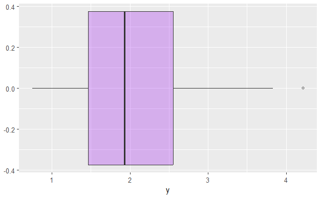

```r
# BOXPLOT
library(ggplot2)
ggplot(diabetes2, aes(y)) +
  geom_boxplot(fill = c("purple"),
               alpha = 0.3) +
  theme(legend.position = "none")
```

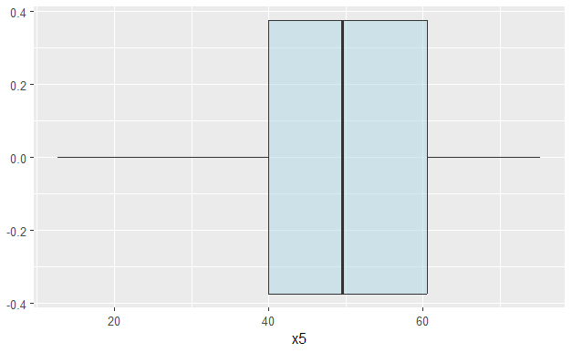

```r
library(ggplot2)
ggplot(diabetes2, aes(x5)) +
  geom_boxplot(fill = c("lightblue"),
               alpha = 0.5) +
  theme(legend.position = "none")
```

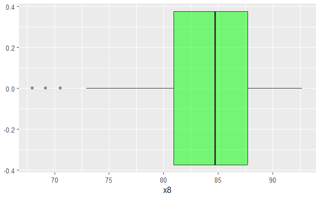

```r
library(ggplot2)
ggplot(diabetes2, aes(x8)) +
  geom_boxplot(fill = c("green"),
               alpha = 0.5) +
  theme(legend.position = "none")
```

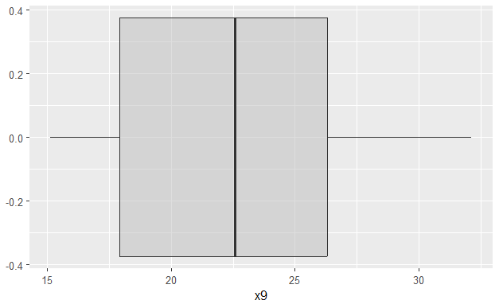

```r
library(ggplot2)
ggplot(diabetes2, aes(x9)) +
  geom_boxplot(fill = c("grey"),
               alpha = 0.5) +
  theme(legend.position = "none")
```

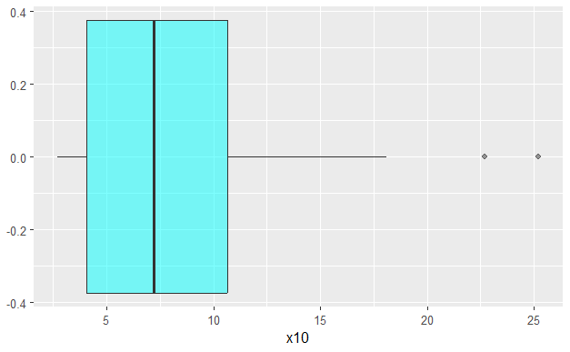

```r
library(ggplot2)
ggplot(diabetes2, aes(x10)) +
  geom_boxplot(fill = c("cyan"),
               alpha = 0.5) +
  theme(legend.position = "none")
```

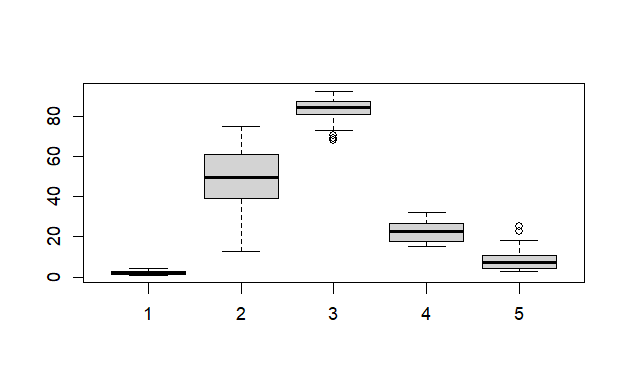

```r
boxplot(diabetes2$y, diabetes2$x5, diabetes2$x8, diabetes2$x9, diabetes2$x10)
```

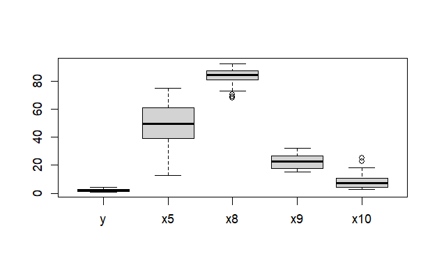

```r
M=data.matrix(diabetes2[, c('y','x5','x8','x9','x10')])

boxplot(M)
```

```r
# == Mendeteksi Pencilan dari Boxplot == #
nilai_outlier1 = boxplot.stats(diabetes2$x8)$out
nilai_outlier2 = boxplot.stats(diabetes2$x10)$out
nilai_outlier1
```

```
[1] 70.54 69.19 67.97
```

```r
nilai_outlier2
```

```
[1] 22.69 25.21
```

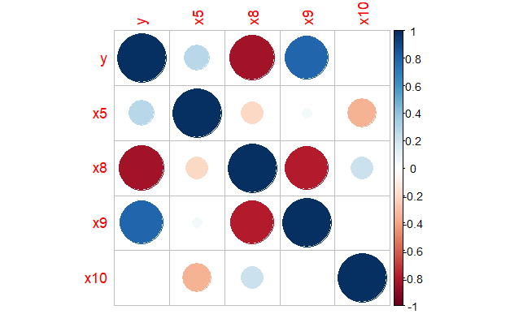

```r
library(corrplot)
korelasi = cor(diabetes2)
corrplot(korelasi)
```

```r
korelasi
```

```
               y          x5         x8           x9          x10
y    1.000000000  0.27079454 -0.8334006  0.798504795 -0.003992592
x5   0.270794544  1.00000000 -0.2082494  0.044618978 -0.349111246
x8  -0.833400650 -0.20824945  1.0000000 -0.781884535  0.217493878
x9   0.798504795  0.04461898 -0.7818845  1.000000000 -0.009348454
x10 -0.003992592 -0.34911125  0.2174939 -0.009348454  1.000000000
```

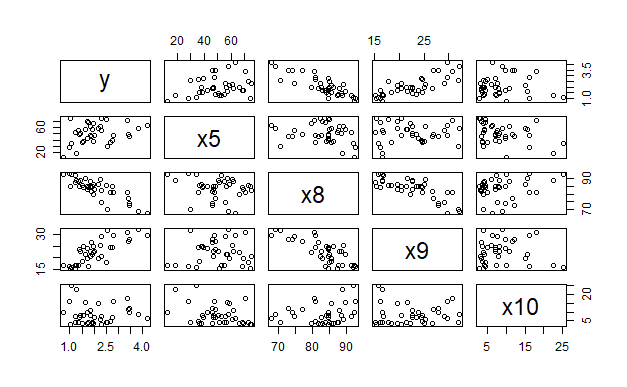

```r
plot(diabetes2[,1:5], pch = 21)
```

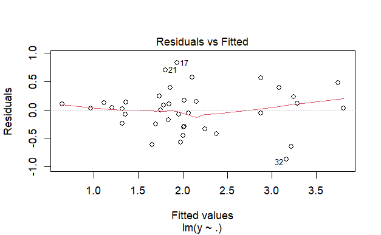

```r
#  ===== Eksplorasi asumsi =====
plot(model2,1)                # plot sisaan vs yduga
```

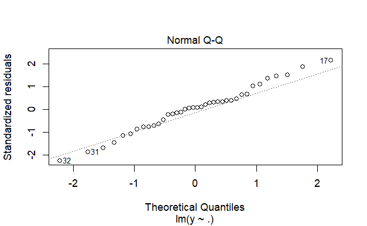

```r
plot(model2,2)                # qq-plot
```

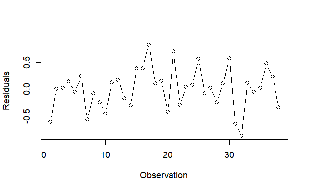

```r
plot(x = 1:dim(diabetes2)[1],
     y = model2$residuals,
     type = 'b',
     ylab = "Residuals",
     xlab = "Observation")       # plot sisaan vs urutan
```

```r
# ===== Uji Asumsi Formal =====
# Asumsi GAUSS MARKOV
# 1 Nilai harapan sisaan sama dengan nol
t.test(model2$residuals,
       mu = 0,
       conf.level = 0.95)
```

```
    One Sample t-test

data:  model2$residuals
t = 8.9198e-17, df = 37, p-value = 1
alternative hypothesis: true mean is not equal to 0
95 percent confidence interval:
 -0.1247617  0.1247617
sample estimates:
  mean of x
5.49234e-18
```

Asumsi terpenuhi karena p-value = 1

```r
# ASUMSI NORMALITAS SISAAN
# Menggunakan Shapiro Wilk Test
ks.test(model2$residuals, "pnorm", mean=mean(model2$residuals), sd=sd(model2$residuals))
```

```
    Exact one-sample Kolmogorov-Smirnov test

data:  model2$residuals
D = 0.098265, p-value = 0.8219
alternative hypothesis: two-sided
```

```r
library(car)
shapiro.test(model2$residuals)
```

```
    Shapiro-Wilk normality test

data:  model2$residuals
W = 0.98596, p-value = 0.9063
```

Hipotesis H0 : Residual berdistribusi normal H1 : Residual tidak berdistribusi normal Keputusan : Karena p-value (0.9063) > alpha (0.05), maka gagal tolak H0 Kesimpulan : Dengan tingkat keyakinan 95%, kita yakin bahwa residual berdistribusi normal.

```r
# Menggunakan Uji Jarque Bera
library("tseries")
residual=resid(model2)
jarque.bera.test(residual)
```

```
    Jarque Bera Test

data:  residual
X-squared = 0.049856, df = 2, p-value = 0.9754
```

Hipotesis H0 : Residual berdistribusi normal H1 : Residual tidak berdistribusi normal Keputusan : Karena p-value (0.9754) > alpha (0.05), maka gagal tolak H0 Kesimpulan : Dengan tingkat keyakinan 95%, kita yakin bahwa residual berdistribusi normal.

```r
# UJI AUTOKORELASI
# Menggunakan Uji Durbin Watson
library(lmtest)
dwtest(model2)
```

```
    Durbin-Watson test

data:  model2
DW = 1.8861, p-value = 0.2289
alternative hypothesis: true autocorrelation is greater than 0
```

Hipotesis H0 : Tidak ada auto korelasi dari galat H1 : Ada auto korelasi dari galat Keputusan : Karena p-value (0.2289) > alpha (0.05), maka gagal tolak H0 Kesimpulan : Dengan tingkat keyakinan 95%, kita yakin bahwa tidak ada auto korelasi pada galat.

```r
# UJI KEHOMOGENAN RAGAM (HOMOSKEDASTISITAS)
# Menggunakan Uji Breusch Pagan
bptest(model2, data=diabetes2)
```

```
    studentized Breusch-Pagan test

data:  model2
BP = 6.2868, df = 4, p-value = 0.1787
```

Hipotesis H0 : Ragam Homogen H1 : Ragam tidak homogen Keputusan : Karena p-value (0.1787) > alpha (0.05) maka gagal tolak H0. Kesimpulan : Dengan tingkat keyakinan 95%, kita yakin bahwa ragam homogen

```r
# UJI MULTIKOLINEARITAS
vif(model2)
```

```
      x5       x8       x9      x10
1.180160 3.002553 2.806365 1.226014
```

Semua variabel memiliki nilai VIF < 10 sehingga tidak mengindikasikan adanya multikolinieritas

```r
ols_vif_tol(model2)
```

| Variables | Tolerance | VIF |
| --- | --- | --- |
| x5 | 0.8473429 | 1.180160 |
| x8 | 0.3330500 | 3.002553 |
| x9 | 0.3563328 | 2.806365 |
| x10 | 0.8156514 | 1.226014 |

Semua variabel memiliki nilai toleransi lebih dari 0.1 dan VIF < 10 sehingga tidak mengindikasikan adanya multikolinieritas

```r
#UJI LINEARITAS
lmtest::resettest(model2, power=2)
```

```
    RESET test

data:  model2
RESET = 0.38951, df1 = 1, df2 = 32, p-value = 0.537
```

p-value = 0.537 > α(0,05) Kesimpulan: model linier.

Kesimpulan: Model regresi memenuhi semua asumsi, dengan variabel bebas x5,x8,x9,x10 dan Adj R-squared = 0.7777 Bentuk Regresi: 6.031956 + (0.011735)x5 - (0.073690)x8 + (0.060262)x9 + (0.029051)x10

```r
# == Model Regresi Robust == #
library(robustbase)
res <- lmrob(y~x5+x8+x9+x10, data=diabetes2)
summary(res)
```

```
Call:
lmrob(formula = y ~ x5 + x8 + x9 + x10, data = diabetes2)
 \--> method = "MM"
Residuals:
     Min       1Q   Median       3Q      Max
-0.91700 -0.22535  0.03514  0.17123  0.82193

Coefficients:
             Estimate Std. Error t value Pr(>|t|)
(Intercept)  6.489381   1.917992   3.383  0.00186 **
x5           0.011368   0.005943   1.913  0.06449 .
x8          -0.078625   0.018801  -4.182  0.00020 ***
x9           0.059474   0.020937   2.841  0.00766 **
x10          0.028755   0.010715   2.684  0.01130 *
---
Signif. codes:  0 ‘***’ 0.001 ‘**’ 0.01 ‘*’ 0.05 ‘.’ 0.1 ‘ ’ 1

Robust residual standard error: 0.3491
Multiple R-squared:  0.8189,    Adjusted R-squared:  0.797
Convergence in 16 IRWLS iterations

Robustness weights:
 2 weights are ~= 1. The remaining 36 ones are summarized as
   Min. 1st Qu.  Median    Mean 3rd Qu.    Max.
 0.4700  0.8578  0.9635  0.8976  0.9916  0.9986
Algorithmic parameters:
       tuning.chi                bb        tuning.psi
        1.548e+00         5.000e-01         4.685e+00
       refine.tol           rel.tol         scale.tol
        1.000e-07         1.000e-07         1.000e-10
        solve.tol       eps.outlier             eps.x
        1.000e-07         2.632e-03         1.686e-10
warn.limit.reject warn.limit.meanrw
        5.000e-01         5.000e-01
     nResample         max.it       best.r.s       k.fast.s
           500             50              2              1
         k.max    maxit.scale      trace.lev            mts
           200            200              0           1000
    compute.rd fast.s.large.n
             0           2000
                  psi           subsampling                   cov
           "bisquare"         "nonsingular"         ".vcov.avar1"
compute.outlier.stats
                 "SM"
seed : int(0)
```

Kesimpulan: Model regresi robust dengan peubah bebas x5,x8,x9,x10 memiliki nilai Adj R-squared tertinggi, yaitu sebesar 0.797. Oleh karena itu diambil model regresi robust dengan bentuk regresi: 6.489381 + (0.011368)x5 - (0.078625)x8 + (0.059474)x9 + (0.028755)x10